# EAE 127 - Project 3: Applied and Computational Aerodynamics

Chung Yin Leung (998238900)

Imports and setup code:

```python
%matplotlib inline
import numpy as np
import math as m
import matplotlib.pyplot as pl
```

## Introduction

In this project, superposition of elementary potential flows are examined for their usability in approximating flows over airfoils. In the first case, a uniform flow is combined with a source. The resultant flow is used to find a dividing streamline, a streamline that contains the stagnation point in a uniform and source flow. Because flow velocity is tangential to a streamline, the dividing streamline can be approximated as the surface of an object. In the second case, a combination of sources, sinks, and a uniform flow is used to find a flow field where the dividing streamline can approximate the NACA 0017 airfoil. In the final case, a row of finite vortices are compared to a row of infinite vorticies. When there is a row of infinite vortices, the flow field is approximately two uniform flows in opposite directions, but the uniform flows are separated by the row of vortices.

### Problem 1: Superposition of Uniform and Source Potential Flows

#### Approach

For this problem, a uniform flow is superpositioned over a source flow. The equations for the stagnation point and dividing streamline in this flow are derived by beginning with equation 3.74 from Anderson's Fundamentals. The velocity components of this flow are found by differentiating equation 3.74. By setting the velocity components to zero, the stagnation point location is found. Substituting the location into equation 3.74 results in the constant for the dividing streamline. Finding the location above the source and at the dividing streamline results in the diameter of the dividing streamline.

The plot is generated by using a mesh grid of x and y values. Using the mesh, stream function values, velocity field values, and velocity potential values are calculated at those combinations of x and y values. The dividing streamline is plotted using a contour of streamline when the stream function equals the constant derived from above.

#### Equations

The stream function for the combination of a uniform flow with a source or sink at the origin is equation 3.74 from Anderson's Fundamentals, where $V_\infty$ is the freestream velocity and $\Lambda$ is the source strength:

\begin{equation} \psi = V_\infty r \sin{\theta} + \frac{\Lambda}{2\pi}\theta \end{equation}

A stream line is defined by a stream function where $\psi$ is a constant $C$, from equation 3.75 of Anderson's Fundamentals:

\begin{equation} \psi = C =V_\infty r \sin{\theta} + \frac{\Lambda}{2\pi}\theta \end{equation}

When the above equation is solved for $r$, a function for the location of streamlines can be found:

\begin{equation} r(\theta) = \frac{1}{V_\infty \sin{\theta}}\left(C - \frac{\Lambda}{2\pi}\theta\right) \end{equation}

The above equation requires $C$ in order to obtain a specific streamline. By inputting $\theta$ values into that equation, an entire streamline can be obtained.

The velocity components in the $r$ and $\theta$ directions can be computed by the following equations, from equations 2.157, 3.76 and 3.77:

\begin{equation} V_r = \frac{1}{r} \frac{\partial \psi}{\partial \theta} = V_\infty \cos{\theta} + \frac{\Lambda}{2\pi r} \end{equation}\begin{equation} V_\theta = -\frac{\partial \psi}{\partial r} = -V_\infty \sin{\theta} \end{equation}

The stagnation point can be obtained by setting the above equations to zero:

\begin{equation} V_r = V_\infty \cos{\theta_s} + \frac{\Lambda}{2\pi r_s} = 0 \end{equation}\begin{equation} V_\theta = -V_\infty \sin{\theta_s} = 0 \end{equation}

Solving the $V_\theta$ equation for $\theta_s$, $\theta_s = 0$, and $\theta_s = \pi$. Solving the $V_r$ equation for $r_s$, $r_s = -\frac{\Lambda}{2\pi V_\infty}$, and $r_s = \frac{\Lambda}{2\pi V_\infty}$

There is one stagnation point because both locations is at the same point. The stagnation point is upstream at $(r,\theta) = (\frac{\Lambda}{2\pi V_\infty},\pi)$. Plugging in the point's location into the the stream function results in the constant needed for the dividing streamline:

\begin{equation} \psi=V_\infty (-\frac{\Lambda}{2\pi V_\infty}) (\sin{\pi}) + \frac{\Lambda}{2\pi}(\pi) = \frac{\Lambda}{2} \end{equation}

Using this constant and the stream function, an equation for the streamline can be found in terms of $\theta$ or $r$. The following equation gives $r$ in terms of $\theta$:

\begin{equation} r(\theta) = \frac{\Lambda}{2\pi V_\infty \sin{\theta}} \left(\pi - \theta\right) \end{equation}

If the source is at the origin, the dividing streamline diameter $r_d$ can be found by finding $r$ at $\frac{\pi}{2}$ or at $\frac{\pi}{2}$:

\begin{equation} r_d = r(\frac{\pi}{2}) = \frac{\Lambda}{4V_\infty} \end{equation}

All of the above equations can be transformed into $x$ and $y$ coordinates using the following transformation equations:

\begin{equation} x = r \cos{\theta} \end{equation}\begin{equation} y = r \sin{\theta} \end{equation}\begin{equation} \theta = \arctan{\frac{y}{x}} \end{equation}

The stream function becomes:

\begin{equation} \psi = V_\infty y + \frac{\Lambda}{2\pi}\arctan{\frac{y}{x}} \end{equation}

The first term is the stream function for a uniform flow, and the second term is the stream function for a source at the origin.

The velocity components in the $x$ and $y$ directions are:

\begin{equation} V_x = \frac{\partial \psi}{\partial y} = V_\infty + \frac{\Lambda}{2\pi}\left(\frac{x}{x^2 + y^2}\right) \end{equation}

The first term is the velocity for a uniform flow, and the second term is the velocity for a source at the origin.

\begin{equation} V_y = -\frac{\partial \psi}{\partial x} = \frac{\Lambda}{2\pi}\left(\frac{y}{x^2 + y^2}\right) \end{equation}

The uniform flow has zero velocity in the $y$-direction, so the above equation is the velocity from a source at the origin. The upstream stagnation point in $x$-$y$ coordinates is $(x,y) = \left(-\frac{\Lambda}{2\pi V_\infty},0\right)$. Plugging this point into the streamline function results in a streamline function constant of $0$. Finding the $y$ value at the dividing streamline above the source results in the same magnitude for the streamline diameter.

The velocity potential function for this combination can be found by adding the velocity potential function of the uniform flow and a source. For a uniform flow, the velocity potential is as follows:

\begin{equation} \phi_{uniform} = V_\infty x \end{equation}

For a source at the origin, the velocity potential is as follows:

\begin{equation} \phi_{source} = \frac{\Lambda}{4\pi} \ln{(x^2 + y^2)} \end{equation}

For the combination:

\begin{equation} \phi = \phi_{uniform} + \phi_{source} = V_\infty x + \frac{\Lambda}{4\pi} \ln{(x^2 + y^2)} \end{equation}

#### Code and Results

Generate a 2D mesh to calculate stream function values and velocity values.

```python
N = 200                               # Number of points in each direction
x_0, x_f = -4.0, 4.0            # x-direction boundaries
y_0, y_f = -2.0, 2.0            # y-direction boundaries
x = np.linspace(x_0, x_f, N)    # 1D-array for x
y = np.linspace(y_0, y_f, N)    # 1D-array for y
X, Y = np.meshgrid(x, y)              # generates a mesh grid
```

Code to define uniform flow values:

```python
v_inf = 1; #Free stream velocity
#Uniform flow velocity field
vx_unif = np.ones((N,N),dtype = float)*v_inf
vy_unif = np.zeros((N,N),dtype = float)

#Uniform flow stream function
psi_unif = v_inf*Y;
#Uniform flow velocity potential
phi_unif = v_inf*X;
```

Code to define source flow values:

```python
source_lbda = 5; #Source strength
#Source velocity field
vx_source = source_lbda*X/(2*np.pi*(X**2 + Y**2))
vy_source = source_lbda*Y/(2*np.pi*(X**2 + Y**2))

#Source stream function
psi_source = np.arctan2(Y,X)*source_lbda/(2*np.pi)
#Source velocity potential
phi_source = np.log(X**2 + Y**2)*source_lbda/(4*np.pi)
```

Use superposition to calculate the combined field:

```python
#Use superposition to calculate velocity field
vx = vx_unif + vx_source
vy = vy_unif + vy_source
#To calculate stream function
psi = psi_unif + psi_source
#To calculate velocity potential function
phi = phi_unif + phi_source
```

Plots everything, calculates dividing streamline diameter, and stagnation point location:

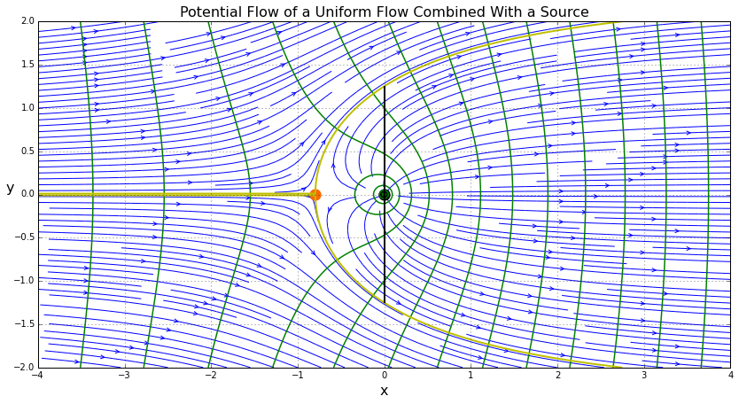

```python
size = 14
pl.figure(figsize=(size, (y_0-y_f)/(x_0-x_f)*size));
pl.grid(True);
pl.xlabel('x', fontsize=16);
pl.ylabel('y', fontsize=16,rotation='horizontal');
pl.title('Potential Flow of a Uniform Flow Combined With a Source', fontsize = 16);
pl.xlim(x_0, x_f);
pl.ylim(y_0, y_f);

#Plots the velocity field
pl.streamplot(X, Y, vx, vy, density=2, linewidth=1, arrowsize=1, arrowstyle='->');

#Plots velocity potentials, equipotential lines
pl.contour(X,Y,phi,15,colors='g', linewidths=1.5, linestyles='solid');

#Adds the dividing streamline to the figure
pl.contour(X, Y, psi,
            levels=[-source_lbda/2, source_lbda/2],
            colors='y', linewidths=2, linestyles='solid');

#Plots dividing streamline diameter
sl_dia = source_lbda/(4*v_inf)
pl.vlines(0,-sl_dia,sl_dia,linewidth = 2, color='k');

#Plots Source location
pl.scatter(0, 0, color='k', s=150, marker='o');

#Calculates the stagnation point
x_stag = -source_lbda/(2*np.pi*v_inf)
y_stag = 0
#Plots stagnation point
pl.scatter(x_stag, y_stag, color='#FF6600', s=150, marker='o');
```

**Figure 1: Potential Flow of a Uniform Flow Combined With a Source**

Figure 1 shows the velocity field and equipotential lines of a uniform flow parallel to the x-axis superpositioned onto a source located at the origin. The velocity field are the blue lines with arrows. The equipotential lines are green. The orange point is the stagnation point, and the black point is the location of the source. The yellow line is the dividing streamline, and the black line connects the source to the dividing streamline in both directions. Half of the black line equals the dividing streamline diameter.

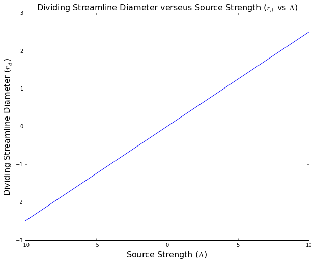

```python
#Generate source strenght values
lbda = np.linspace(-10,10,100)
#Calculate diameter values
rd = lbda/(4*v_inf)
#Plot the dividing streamline diameter vs source strength
pl.figure(figsize=(10,8));
pl.plot(lbda,rd);
#Annotations
pl.xlabel('Source Strength ($\Lambda$)', fontsize=16);
pl.ylabel('Dividing Streamline Diameter ($r_d$)', fontsize=16);
pl.title('Dividing Streamline Diameter verseus Source Strength ($r_d$ vs $\Lambda$)', fontsize = 16);
```

Figure 2 is a plot of the dividing streamline diameter as a function of source strength. From the plot, the dividing streamline diameter is directly proportional to the source strength. The exact slope is $\left(\frac{1}{4V_\infty}\right)$.

### Problem 2: Potential Flow Airfoil Representation

#### Approach

For this problem, the NACA 0017 airfoil's geometry is generated using the NACA thickness equation, and a series of sources and sinks in a uniform flow is used to approximate the NACA 0017 airfoil's geometry.

The series of sources and sinks are placed equally spaced on the chord line of the airfoil. Each source and sink comes as a set based around one central location on the chord. One distance is defined as an offset from the central location to the source, and another distance is defined as an offset from the central location to the sink. The strength of the source-sink set is directly proportional to the thickness of the NACA 0017 at the location the set is based around. The proportion constant is changed in order to fit the airfoil better, but the overall shape is defined by the number of source-sink sets, and the offsets of the source and sink. The accuracy of the approximation can be determined by taking the magnitude of the difference of the dividing streamline's y-values and the airfoil's actual y-values at the same x-position.

When the combination of sources and sinks' strengths sums to zero, the dividing streamline is defined by a stream function of zero. Because the sources and sinks come in sets, the net strength will always be zero no matter how much sets of sources and sinks are defined.

#### Equations

The stream function for a source can be rewritten to allow a source to be placed anywere in a grid. If $x_s$ and $y_s$ denotes the location of a source, the stream function is written as follows:

\begin{equation} \psi_{source} = \frac{\Lambda}{2\pi}\arctan{\frac{y-y_s}{x-x_s}} \end{equation}

And the velocity components are defined as follows:

\begin{equation} V_{x, source} = \frac{\Lambda}{2\pi}\left[\frac{x-x_s}{(x-x_s)^2 + (y-y_s)^2}\right] \end{equation}\begin{equation} V_{y, source} = \frac{\Lambda}{2\pi}\left[\frac{y-y_s}{(x-x_s)^2 + (y-y_s)^2}\right] \end{equation}

And the uniform flow can act at an angle $\alpha$ with respect to the $x$-axis. The stream function for a uniform flow with an angle $\alpha$ is:

\begin{equation} \psi_{uniform} = V_\infty (y\cos{\alpha} - x\sin{\alpha}) \end{equation}

And the velocity components are defined as follows:

\begin{equation} V_{x, uniform} = V_\infty \cos{\alpha} \end{equation}\begin{equation} V_{y, uniform} = V_\infty \sin{\alpha} \end{equation}

The quantified error is calculate using the following equation, where $y_t$ is the $y$-location of the airfoil and $y_{contour}$ is the $y$-value of the dividing streamline:

\begin{equation} Error = \left|y_t - y_{contour}\right| \end{equation}

The thickness of the NACA 0017 airfoil is calculated using the following equation, where $t = 0.17$ and $c = 1$:

\begin{equation} y_t\left(\frac{x}{c}\right)=\frac{t}{0.2} c\left[0.2969\sqrt{\frac{x}{c}}-0.1260\frac{x}{c}-0.3516\left(\frac{x}{c}\right)^2+0.2843\left(\frac{x}{c}\right)^3-0.1015\left(\frac{x}{c}\right)^4 \right] \end{equation}

#### Code and Results

The following code defines several functions:

```python
def unif_psi(v_inf, alpha, X, Y):
    """Returns the stream function values of a uniform flow across given mesh grid.

    Arguments
    ---------
    v_inf -- Free stream velocity.
    alpha -- Angle of free stream velocity with respect to x-axis.
    X -- X array mesh grid.
    Y -- Y array mesh grid.
    """
    psi = v_inf*Y
    return psi

def unif_vfd(v_inf, alpha, X, Y):
    """Returns the velocity field distribution of a uniform flow across given mesh grid.

    Arguments
    ---------
    v_inf -- Free stream velocity.
    alpha -- Angle of free stream velocity with respect to x-axis.
    X -- X array mesh grid.
    Y -- Y array mesh grid.
    """
    shape = np.shape(X)
    vx = np.ones(shape, dtype=float)*v_inf*np.cos(alpha)
    vy = np.ones(shape, dtype=float)*v_inf*np.sin(alpha)
    return vx, vy

def source_psi(lbda, x_s, y_s, X, Y):
    """Returns the stream function values of a source/sink across given mesh grid.

    Arguments
    ---------
    lbda -- Source/Sink strength. Positive for source. Negative for sink.
    x_s -- x-location of source/sink.
    y_s -- x-location of source/sink.
    X -- X array mesh grid.
    Y -- Y array mesh grid.
    """
    psi = np.arctan2(Y - y_s, X - x_s)*lbda/(2*np.pi)
    return psi

def source_vfd(lbda, x_s, y_s, X, Y):
    """Returns the velocity field distribution of a source/sink across given mesh grid.

    Arguments
    ---------
    lbda -- Source/Sink strength. Positive for source. Negative for sink.
    x_s -- x-location of source/sink.
    y_s -- x-location of source/sink.
    X -- X array mesh grid.
    Y -- Y array mesh grid.
    """
    vx = (X - x_s)*lbda/(2*np.pi*((X - x_s)**2 + (Y - y_s)**2))
    vy = (Y - y_s)*lbda/(2*np.pi*((X - x_s)**2 + (Y - y_s)**2))
    return vx, vy

def zt(xc):
    """The thickness value/y-value of a NACAXX17 airfoil at a chordwise x-position

    Arguments
    ---------
    xc -- Chordwise x-position
    """
    t = 0.17
    c = 1
    zt = (t/0.2)*c*(0.2969*(xc ** (0.5)) - 0.1260*(xc) - 0.3516*(xc ** 2) + 0.2843*(xc ** 3) - 0.1015*(xc ** 4))
    return zt

def afoil_aprx_psi(n_s,dxp,dxn,s_mult, X, Y):
    """Returns streamline function values for a source/sink, uniform flow combination across the given mesh grid.

    Arguments
    ---------
    n_s -- Number of sets of source & sinks.
    dxp -- Offset of sources.
    dxn -- Offset of sinks.
    s_mult -- Multiplier to thickness value of airfoil for use as source strengths.
    X -- X array of mesh grid.
    Y -- Y array of mesh grid.
    """
    shape = np.shape(X)
    psi = np.zeros(shape, dtype=float) #Initialize stream function array
    x_s = np.linspace(0.05,1,n_s) #Spacing for sources/sinks
    y_s = np.zeros((n_s,1))
    source_strengths = s_mult*zt(x_s)

    for i in range(0,n_s):
        #Negative sources -> sinks
        psi_s = source_psi(-source_strengths[i], x_s[i]+dxn, 0, X, Y)
        psi = psi + psi_s

        #Positive sources
        psi_s = source_psi(source_strengths[i], x_s[i]+dxp, 0, X, Y)
        psi = psi + psi_s

    #Calculate uniform flow stream function
    psi_unif = unif_psi(1, 0, X, Y)

    #Calculate combined stream function
    psi = psi + psi_unif
    return psi, x_s, y_s

def error_foil(ct,i,plot):
    """Returns the quantified error of the dividing streamline approximation of the actual airfoil.

    Arguments
    ---------
    ct -- Contour line object.
    i -- ith path to use to calculate error.
    plot -- Set 1 to plot paths.
    """
    paths =  ct.collections[0].get_paths()

    if plot == 1:
        pl.figure();
        for g in range(0,len(paths)):
            v = paths[g].vertices
            #x vector of contour is first column of vertices
            x_val = v[:, 0]
            #y vector of contour is second column of vertices
            y_val = v[:, 1]
            pl.plot(x_val, y_val,label= str(g) + ' th Path')

        pl.axis('equal')
        pl.title('X, Y Paths of Extracted Contour')
        pl.xlabel('x')
        pl.ylabel('y')
        pl.legend(loc='best')

    path = paths[i]
    v = path.vertices
    #x vector of contour is first column of vertices
    x_val = v[:, 0]
    #y vector of contour is second column of vertices
    y_val = v[:, 1]
    x_foil, y_foil = [], [] #Initialize
    #Gets (x,y) sets for x's between  0 and 3/4 chord and y's above 0. Uses y > 10^-10 to exclude near 0 values at x's > 0
    for x, y in zip(x_val, y_val):
        if x >= 0 and x<=0.75 and y>10**-10:
            x_foil.append(x)
            y_foil.append(y)
    #Convert lists to NumPy arrays
    x_foil = np.array(x_foil)
    y_foil = np.array(y_foil)
    #Calculate the theoretical thickness at obtained x's
    y_th = zt(x_foil)
    #Find error
    error = sum(np.absolute(y_th - y_foil))
    print('Quantified Error:', error)
    return error
```

The following code initializes the mesh grid:

```python
N = 400                               # Number of points in each direction
x_0, x_f = -0.3, 1.2        # x-direction boundaries
y_0, y_f = -0.5, 0.5        # y-direction boundaries
x = np.linspace(x_0, x_f, N)    # 1D-array for x
y = np.linspace(y_0, y_f, N)    # 1D-array for y
X, Y = np.meshgrid(x, y)              # generates a mesh grid
```

The following code defines three source/sink combinations/iterations:

```python
n_s1 = 10 #Number of sources/sinks*0.5 | Sets of sources/sinks
dxp1 = 0 #Offset for sources
dxn1 = 0.1 #Offset for sinks
s_mult1 = 3 #Multiplier of airfoil thickness for source strength

psi1, x_s1, y_s1 = afoil_aprx_psi(n_s1, dxp1, dxn1, s_mult1, X, Y)

n_s2 = 10 #Number of sources/sinks*0.5
dxp2 = -0.02 #Offset for sources
dxn2 = 0.05 #Offset for sinks
s_mult2 = 3 #Multiplier of airfoil thickness for source strength

psi2, x_s2, y_s2 = afoil_aprx_psi(n_s2, dxp2, dxn2, s_mult2, X, Y)

n_s3 = 15 #Number of sources/sinks*0.5
dxp3 = -0.02 #Offset for sources
dxn3 = 0.0325 #Offset for sinks
s_mult3 = 3.2 #Multiplier of airfoil thickness for source strength

psi3, x_s3, y_s3 = afoil_aprx_psi(n_s3, dxp3, dxn3, s_mult3, X, Y)
```

The following code plots the results from the first set of sources/sinks:

```
Quantified Error: 3.12340809008
```

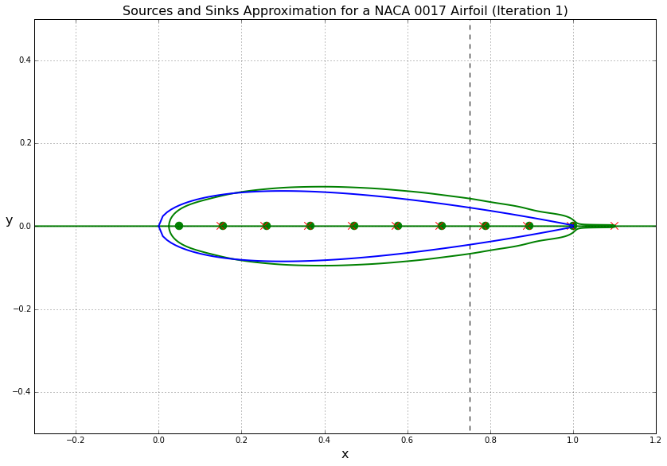

```python
#Figure initialization
size = 14
pl.figure(figsize=(size, (y_0-y_f)/(x_0-x_f)*size));
pl.grid(True);
pl.xlabel('x', fontsize=16);
pl.ylabel('y', fontsize=16,rotation='horizontal');
pl.title('Sources and Sinks Approximation for a NACA 0017 Airfoil (Iteration 1)', fontsize = 16);
pl.xlim(x_0, x_f);
pl.ylim(y_0, y_f);

#Plots locations of sources & sinks
pl.scatter(x_s1+dxp1, y_s1, s=90, color='g')
pl.scatter(x_s1+dxn1, y_s1, s=90, marker='x', color='r')
#Plots location of 3/4 chord
pl.vlines(0.75, -1, 1, linestyles='--')

#Calculate thicknesses of a NACA 0017 airfoil
xc = np.linspace(0,1,100)
th = zt(xc)
#Plots airfoil geometry
pl.plot(xc, th, xc, -th, color = 'b', linewidth = 2);
#Plots dividing streamline
ct1 = pl.contour(X, Y, psi1, levels=[0.0], colors='g', linewidths=2, linestyles='solid');

#Errors
error1 = error_foil(ct1, 0, 0)
```

**Figure 3: First Iteration of Sources and Sinks Approximation for a NACA 0017 Airfoil**

Figure 3 shows the dividing streamline approximation from the first iteration of parameters for the sets of sources and sinks. The dividing streamline is shown in green while the NACA 0017 airfoil geometry is shown in blue. The green dots represent sources while the red crosses represent sinks. The black dashed line represent the third-quarter of the chord.

With these parameters, the approximation is shifted to the right from the airfoil. This can be fixed by applying a negative change to both the source offset and the sink offset. The quantified error with these parameters is $3.123$.

The following code plots the results from the second set of sources/sinks:

```
Quantified Error: 2.46544128714
```

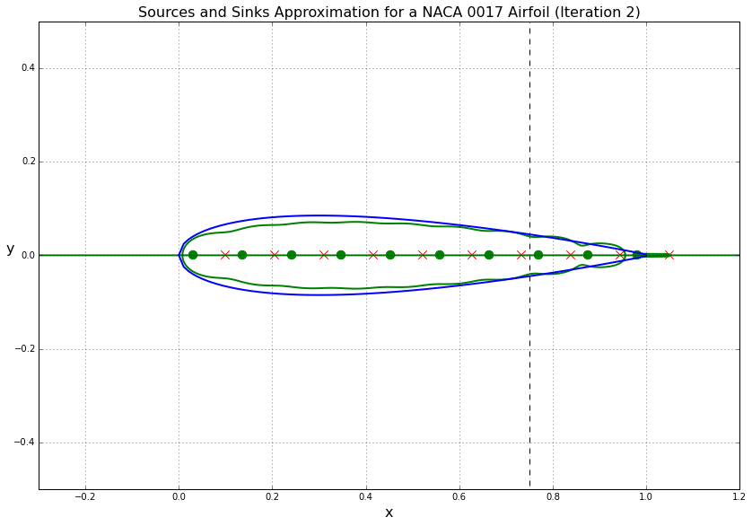

```python
#Figure initialization
size = 14
pl.figure(figsize=(size, (y_0-y_f)/(x_0-x_f)*size));
pl.grid(True);
pl.xlabel('x', fontsize=16);
pl.ylabel('y', fontsize=16,rotation='horizontal');
pl.title('Sources and Sinks Approximation for a NACA 0017 Airfoil (Iteration 2)', fontsize = 16);
pl.xlim(x_0, x_f);
pl.ylim(y_0, y_f);

#Plots locations of sources & sinks
pl.scatter(x_s2+dxp2, y_s2, s=90, color='g')
pl.scatter(x_s2+dxn2, y_s2, s=90, marker='x', color='r')
pl.vlines(0.75, -1, 1, linestyles='--')

#Calculate thicknesses of a NACA 0017 airfoil
xc = np.linspace(0,1,100)
th = zt(xc)
#Plots airfoil geometry
pl.plot(xc, th, xc, -th, color = 'b', linewidth = 2);
#Plots dividing streamline
ct2 = pl.contour(X, Y, psi2, levels=[0.0], colors='g', linewidths=2, linestyles='solid');

#Errors
error2 = error_foil(ct2, 1, 0)
```

**Figure 4: Second Iteration of Sources and Sinks Approximation for a NACA 0017 Airfoil**

Figure 4 shows the dividing streamline approximation from the second iteration of parameters for the sets of sources and sinks. The dividing streamline is shown in green while the NACA 0017 airfoil geometry is shown in blue. The green dots represent sources while the red crosses represent sinks. The black dashed line represent the third-quarter of the chord.

The negative change to both the source offset and the sink offset is applied, and the resultant streamline is shifted to the left. With a smaller sink distance, the overall streamline shrinked. This can be fixed by adding more sources and sets. With these parameters, the quantified error is $2.465$.

The following code plots the results from the third set of sources/sinks:

```
Quantified Error: 0.96852550646
```

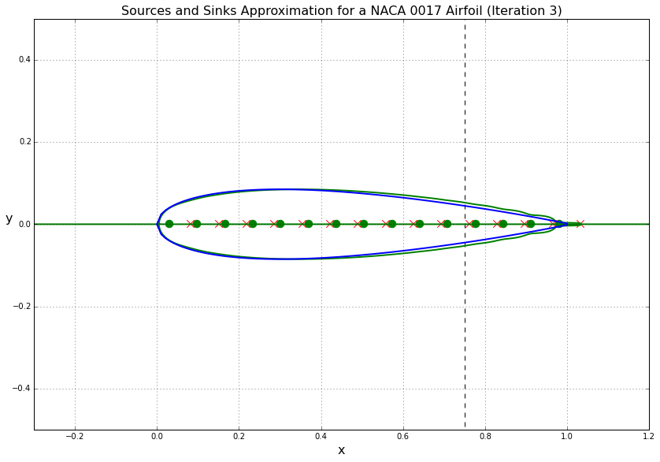

```python
#Figure initialization
size = 14
pl.figure(figsize=(size, (y_0-y_f)/(x_0-x_f)*size));
pl.grid(True);
pl.xlabel('x', fontsize=16);
pl.ylabel('y', fontsize=16,rotation='horizontal');
pl.title('Sources and Sinks Approximation for a NACA 0017 Airfoil (Iteration 3)', fontsize = 16);
pl.xlim(x_0, x_f);
pl.ylim(y_0, y_f);

#Plots locations of sources & sinks
pl.scatter(x_s3+dxp3, y_s3, s=90, color='g')
pl.scatter(x_s3+dxn3, y_s3, s=90, marker='x', color='r')
pl.vlines(0.75, -1, 1, linestyles='--')

#Calculate thicknesses of a NACA 0017 airfoil
xc = np.linspace(0,1,100)
th = zt(xc)
#Plots airfoil geometry
pl.plot(xc, th, xc, -th, color = 'b', linewidth = 2);
#Plots dividing streamline
ct3 = pl.contour(X, Y, psi3, levels=[0.0], colors='g', linewidths=2, linestyles='solid');

#Errors
error3 = error_foil(ct3, 2, 0)
```

**Figure 5: Final Iteration of Sources and Sinks Approximation for a NACA 0017 Airfoil**

Figure 5 shows the dividing streamline approximation from the final iteration of parameters for the sets of sources and sinks. The dividing streamline is shown in green while the NACA 0017 airfoil geometry is shown in blue. The green dots represent sources while the red crosses represent sinks. The black dashed line represent the third-quarter of the chord.

The additional sets of sources and sinks smoothed out the airfoil. Manipulating these parameters further, the final parameters produced a quantified error of $0.9685$.

This method of approximating an airfoil requires trial and error which may take a lot of time depending on the geometry of the airfoil. It cannot produce a dividing streamline that completely conforms to the airfoil around the trailing edge. Because of that, any pressure distribution obtained from using this approximation will never produce the actual lift force that the airfoil experiences. This method can be improved if a recursive method is used where sources and sinks are added and adjusted until the dividing streamline conforms to the airfoil perfectly. But this will also take too much time because of the computing power required.

### Problem 3: More Potential Flow

#### Approach

This problem examines a velocity field generated by a row of infinite vortices. A row of finite vortices is used to approximate the velocity field solution to the row of infinite vortices. Equations for the velocity components of a vortex are used. Vortices are generated across the positive and negative x-axis with a spacing of $a$ between each vortex.

#### Equations

For a vortex flow, the stream function is given by the following equation, where $\Gamma$ is the vortex strength:

\begin{equation} \psi_{vortex} = \frac{\Gamma}{2\pi} \ln{r} = \frac{\Gamma}{4\pi} \ln{\left[(x-x_v)^2 + (y-y_v)^2\right]} \end{equation}

The velocity components in the $x$ and $y$ directions are as follows:

\begin{equation} V_x = \frac{\Gamma}{2\pi} \left[\frac{y-y_v}{(x-x_v)^2 + (y-y_v)^2}\right] \end{equation}\begin{equation} V_y = -\frac{\Gamma}{2\pi} \left[\frac{x-x_v}{(x-x_v)^2 + (y-y_v)^2}\right] \end{equation}

#### Code and Results

Defines functions for the streamline function, velocity component equations for a vortex, and the velocity components for a row of infinite vortices:

```python
def vort_psi(gamma, x_v, y_v, X, Y):
    psi = np.log((X-x_v)**2 + (Y-y_v)**2)*gamma/(4*np.pi)
    return psi

def vort_vfd(gamma, x_v, y_v, X, Y):
    vx = gamma*(Y-y_v)/(2*np.pi*((X-x_v)**2 + (Y-y_v)**2))
    vy = -1*gamma*(X-x_v)/(2*np.pi*((X-x_v)**2 + (Y-y_v)**2))
    return vx, vy

def vort_inf_vfd(gamma, a, X, Y):
    vx = gamma*np.sinh(2*np.pi*Y/a)/(2*np.pi*(np.cosh(2*np.pi*Y/a) - np.cos(2*np.pi*X/a)))
    vy = gamma*np.sin(2*np.pi*X/a)/(2*np.pi*(np.cosh(2*np.pi*Y/a) - np.cos(2*np.pi*X/a)))
    return vx, vy
```

Initializes the mesh grid:

```python
N = 400                               # Number of points in each direction
x_0, x_f = -4, 4            # x-direction boundaries
y_0, y_f = -4, 4            # y-direction boundaries
x = np.linspace(x_0, x_f, N)    # 1D-array for x
y = np.linspace(y_0, y_f, N)    # 1D-array for y
X, Y = np.meshgrid(x, y)              # generates a mesh grid
```

Initializes vortex row parameters:

```python
vortex_strength = 1; #Vortex strength
dx_v = 0.5 #Vortex spacing
```

Finite vortex row with 11 vortices:

```python
n_v1 = 11 #Number of vortices (10, 100, 500) <- 500 is a good approximation
rg1 = dx_v*(n_v1-1)/2 #Range to extend over +x-axis (negative for -x-axis)

x_v1 = np.linspace(-rg1, rg1, n_v1) #x-locations of vortices spread across the x-axis, centered at origin
y_v1 = np.zeros((n_v1,1)) #y-locations of vortices: all 0's on x-axis

#Initialize velocity field totals
vx_t1 = np.zeros((N,N), dtype=float)
vy_t1 = np.zeros((N,N), dtype=float)

#Sums up streamline function values and velocity field
for i in range(0,len(x_v1)):
    vx,vy = vort_vfd(vortex_strength, x_v1[i], y_v1[i], X, Y)

    vx_t1 = vx_t1 + vx
    vy_t1 = vy_t1 + vy
```

Finite vortex row with 101 vortices:

```python
n_v2 = 101 #Number of vortices (10, 100, 500) <- 500 is a good approximation
rg2 = dx_v*(n_v2-1)/2 #Range to extend over +x-axis (negative for -x-axis)

x_v2 = np.linspace(-rg2, rg2, n_v2) #x-locations of vortices spread across the x-axis, centered at origin
y_v2 = np.zeros((n_v2,1))

#Initialize velocity field totals
vx_t2 = np.zeros((N,N), dtype=float)
vy_t2 = np.zeros((N,N), dtype=float)

for i in range(0,len(x_v2)):
    vx,vy = vort_vfd(vortex_strength, x_v2[i], y_v2[i], X, Y)

    vx_t2 = vx_t2 + vx
    vy_t2 = vy_t2 + vy
```

Finite vortex row with 501 vortices:

```python
n_v3 = 501 #Number of vortices (10, 100, 500) <- 500 is a good approximation
rg3 = dx_v*(n_v3-1)/2 #Range to extend over +x-axis (negative for -x-axis)

x_v3 = np.linspace(-rg3, rg3, n_v3) #x-locations of vortices spread across the x-axis, centered at origin
y_v3 = np.zeros((n_v3,1))

#Initialize velocity field totals
vx_t3 = np.zeros((N,N), dtype=float)
vy_t3 = np.zeros((N,N), dtype=float)

for i in range(0,len(x_v3)):
    vx,vy = vort_vfd(vortex_strength, x_v3[i], y_v3[i], X, Y)

    vx_t3 = vx_t3 + vx
    vy_t3 = vy_t3 + vy
```

Plotting first set of finite vortices:

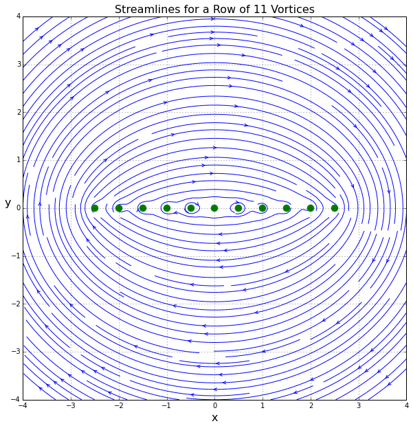

```python
size = 10
pl.figure(figsize=(size, (y_0-y_f)/(x_0-x_f)*size));
pl.grid(True);
pl.xlabel('x', fontsize=16);
pl.ylabel('y', fontsize=16,rotation='horizontal');
pl.title('Streamlines for a Row of 11 Vortices', fontsize = 16);
pl.xlim(x_0, x_f);
pl.ylim(y_0, y_f);

#Plots the velocity field
sup = pl.streamplot(X, Y, vx_t1, vy_t1, density=2, color='b', linewidth=1, arrowsize=1, arrowstyle='->')

#Plots locations of vortices
pl.scatter(x_v1, y_v1, s=90, color='g');
```

**Figure 6: Streamlines of a Row of 11 Vortices**

Figure 6 shows the streamlines for a row of 11 vortices. The green dots are locations of each individual vortex. With 11 vortices and a 8-by-8 square view of the origin, the streamlines are still elliptical.

Plotting second set of finite vortices:

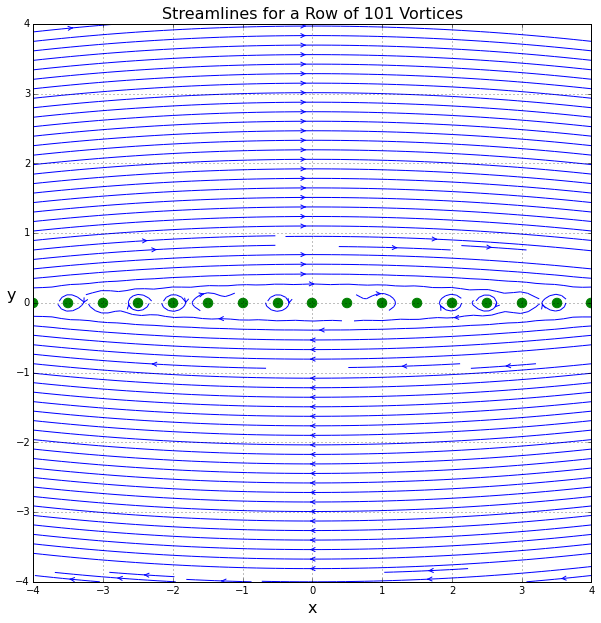

```python
size = 10
pl.figure(figsize=(size, (y_0-y_f)/(x_0-x_f)*size));
pl.grid(True);
pl.xlabel('x', fontsize=16);
pl.ylabel('y', fontsize=16,rotation='horizontal');
pl.title('Streamlines for a Row of 101 Vortices', fontsize = 16);
pl.xlim(x_0, x_f);
pl.ylim(y_0, y_f);

#Plots the velocity field
sup = pl.streamplot(X, Y, vx_t2, vy_t2, density=2, color='b', linewidth=1, arrowsize=1, arrowstyle='->')

#Plots locations of vortices
pl.scatter(x_v2, y_v2, s=90, color='g');
```

**Figure 7: Streamlines of a Row of 101 Vortices**

Figure 7 shows the streamlines for a row of 101 vortices. The green dots are locations of each individual vortex. With 101 vortices and a 8-by-8 square view of the origin, the streamlines are beginning to straighten out.

Plotting third set of finite vortices:

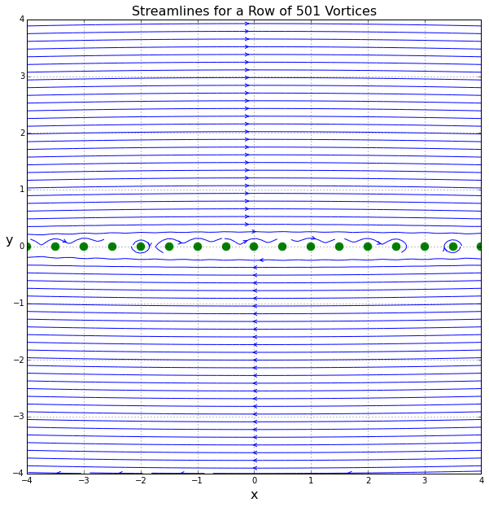

```python
size = 10
pl.figure(figsize=(size, (y_0-y_f)/(x_0-x_f)*size));
pl.grid(True);
pl.xlabel('x', fontsize=16);
pl.ylabel('y', fontsize=16,rotation='horizontal');
pl.title('Streamlines for a Row of 501 Vortices', fontsize = 16);
pl.xlim(x_0, x_f);
pl.ylim(y_0, y_f);

#Plots the velocity field
sup = pl.streamplot(X, Y, vx_t3, vy_t3, density=2, color='b', linewidth=1, arrowsize=1, arrowstyle='->')

#Plots locations of vortices
pl.scatter(x_v3, y_v3, s=90, color='g');
```

**Figure 8: Streamlines of a Row of 501 Vortices**

Figure 8 shows the streamlines for a row of 501 vortices. The green dots are locations of each individual vortex. With 501 vortices and a 8-by-8 square view of the origin, the streamlines are approximately equal to the streamlines created by a row of infinite vortices.

Calculates and plot the theoretical velocity field for a row of infinite vortices:

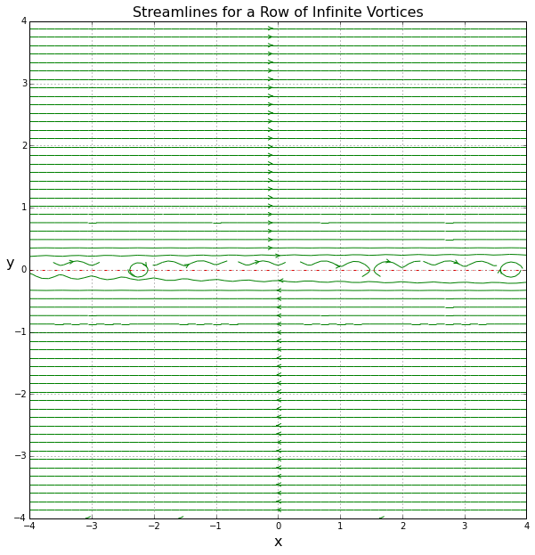

```python
#Calculates theoretical velocity field of a row of infinite vortices
vx_inf, vy_inf = vort_inf_vfd(vortex_strength, dx_v, X, Y)

size = 10
pl.figure(figsize=(size, (y_0-y_f)/(x_0-x_f)*size));
pl.grid(True);
pl.xlabel('x', fontsize=16);
pl.ylabel('y', fontsize=16,rotation='horizontal');
pl.title('Streamlines for a Row of Infinite Vortices', fontsize = 16);
pl.xlim(x_0, x_f);
pl.ylim(y_0, y_f);
#Plots the velocity field
sup = pl.streamplot(X, Y, vx_inf, vy_inf, density=2, color='g', linewidth=1, arrowsize=1, arrowstyle='->');
pl.hlines(0, -4, 4, color='r', linestyle='-.');
```

**Figure 9: Streamlines of a Row of Infinite Vortices**

Figure 9 shows the streamlines for a row of infinite vortices. The red dashed-dotted line represents the location of each individual vortex if they are seeable. Figure 8 with 501 vortices are very close to Figure 9 with infinite vortices.

A row of infinite vortices generate two uniform flows in opposite directions. The uniform flows are separated by the row of vortices. Because the streamlines are perfectly parallel, multiple rows of vortices can generate straight streamlines to approximate the surface of an object. With infinitesimally sized rows, curvatures of an airfoil could be approximated, and other more complex surfaces could also be modeled.

## Conclusion

The streamlines of a potential flow can behave like the surface of an object. If a streamline crosses a stagnation point,that streamline is considered to be a dividing streamline which is a streamline that can represent the surface of an object and prevents any flow inside to interact with the flow outside. If a dividing streamline is enclosed, the streamline can replace an object with the same geometry in the flow, and the resultant flow field can be used to predict the lift force on the object.

A method of generating a dividng streamline is to use a uniform flow and a source flow. A stagnation point occurs upstream of the source, and the dividing streamline spreads from that point. Expanding on this method by adding a sink of the same strength generates a an enclosed dividing streamline. By using multiple sets of sources and sinks of the same strength within a uniform flow, a good approximation of the geometry of an airfoil can be produced by the resultant dividing streamline.

The last method is to use rows of infinite vortices. Because infinite vortices produce a two separate, non-interacting uniform flows, they can act as walls or surfaces of an object. If rows of infinite vortices are connected together, a physical object can be represented in the flow field.